# 52414 - lab 1

52414

4/4/2020

# *Lab 1: Basic Data Wrangling*

The only allowed libraries are the following (**please do not add your own**):

### Q1

### Data Preparation and Manipulation

(25 points)

**Solution:**

```r
#open filles
conf.cases.nar <- read.csv(url("https://data.humdata.org/hxlproxy/data/download/time_series_covid19_confirmed_global_narrow.csv?dest=data_edit&filter01=explode&explode-header-att01=date&explode-value-att01=value&filter02=rename&rename-oldtag02=%23affected%2Bdate&rename-newtag02=%23date&rename-header02=Date&filter03=rename&rename-oldtag03=%23affected%2Bvalue&rename-newtag03=%23affected%2Binfected%2Bvalue%2Bnum&rename-header03=Value&filter04=clean&clean-date-tags04=%23date&filter05=sort&sort-tags05=%23date&sort-reverse05=on&filter06=sort&sort-tags06=%23country%2Bname%2C%23adm1%2Bname&tagger-match-all=on&tagger-default-tag=%23affected%2Blabel&tagger-01-header=province%2Fstate&tagger-01-tag=%23adm1%2Bname&tagger-02-header=country%2Fregion&tagger-02-tag=%23country%2Bname&tagger-03-header=lat&tagger-03-tag=%23geo%2Blat&tagger-04-header=long&tagger-04-tag=%23geo%2Blon&header-row=1&url=https%3A%2F%2Fraw.githubusercontent.com%2FCSSEGISandData%2FCOVID-19%2Fmaster%2Fcsse_covid_19_data%2Fcsse_covid_19_time_series%2Ftime_series_covid19_confirmed_global.csv"), comment.char="#",  stringsAsFactors = FALSE)

death.cases.nar <- read.csv(url("https://data.humdata.org/hxlproxy/data/download/time_series_covid19_deaths_global_narrow.csv?dest=data_edit&filter01=merge&merge-url01=https%3A%2F%2Fdocs.google.com%2Fspreadsheets%2Fd%2Fe%2F2PACX-1vTglKQRXpkKSErDiWG6ycqEth32MY0reMuVGhaslImLjfuLU0EUgyyu2e-3vKDArjqGX7dXEBV8FJ4f%2Fpub%3Fgid%3D1326629740%26single%3Dtrue%26output%3Dcsv&merge-keys01=%23country%2Bname&merge-tags01=%23country%2Bcode%2C%23region%2Bmain%2Bcode%2C%23region%2Bsub%2Bcode%2C%23region%2Bintermediate%2Bcode&filter02=merge&merge-url02=https%3A%2F%2Fdocs.google.com%2Fspreadsheets%2Fd%2Fe%2F2PACX-1vTglKQRXpkKSErDiWG6ycqEth32MY0reMuVGhaslImLjfuLU0EUgyyu2e-3vKDArjqGX7dXEBV8FJ4f%2Fpub%3Fgid%3D398158223%26single%3Dtrue%26output%3Dcsv&merge-keys02=%23adm1%2Bname&merge-tags02=%23country%2Bcode%2C%23region%2Bmain%2Bcode%2C%23region%2Bsub%2Bcode%2C%23region%2Bintermediate%2Bcode&merge-replace02=on&merge-overwrite02=on&filter03=explode&explode-header-att03=date&explode-value-att03=value&filter04=rename&rename-oldtag04=%23affected%2Bdate&rename-newtag04=%23date&rename-header04=Date&filter05=rename&rename-oldtag05=%23affected%2Bvalue&rename-newtag05=%23affected%2Binfected%2Bvalue%2Bnum&rename-header05=Value&filter06=clean&clean-date-tags06=%23date&filter07=sort&sort-tags07=%23date&sort-reverse07=on&filter08=sort&sort-tags08=%23country%2Bname%2C%23adm1%2Bname&tagger-match-all=on&tagger-default-tag=%23affected%2Blabel&tagger-01-header=province%2Fstate&tagger-01-tag=%23adm1%2Bname&tagger-02-header=country%2Fregion&tagger-02-tag=%23country%2Bname&tagger-03-header=lat&tagger-03-tag=%23geo%2Blat&tagger-04-header=long&tagger-04-tag=%23geo%2Blon&header-row=1&url=https%3A%2F%2Fraw.githubusercontent.com%2FCSSEGISandData%2FCOVID-19%2Fmaster%2Fcsse_covid_19_data%2Fcsse_covid_19_time_series%2Ftime_series_covid19_deaths_global.csv"), comment.char="#",  stringsAsFactors = FALSE)

recovered.cases.nar <- read.csv(url("https://data.humdata.org/hxlproxy/data/download/time_series_covid19_recovered_global_narrow.csv?dest=data_edit&filter01=merge&merge-url01=https%3A%2F%2Fdocs.google.com%2Fspreadsheets%2Fd%2Fe%2F2PACX-1vTglKQRXpkKSErDiWG6ycqEth32MY0reMuVGhaslImLjfuLU0EUgyyu2e-3vKDArjqGX7dXEBV8FJ4f%2Fpub%3Fgid%3D1326629740%26single%3Dtrue%26output%3Dcsv&merge-keys01=%23country%2Bname&merge-tags01=%23country%2Bcode%2C%23region%2Bmain%2Bcode%2C%23region%2Bsub%2Bcode%2C%23region%2Bintermediate%2Bcode&filter02=merge&merge-url02=https%3A%2F%2Fdocs.google.com%2Fspreadsheets%2Fd%2Fe%2F2PACX-1vTglKQRXpkKSErDiWG6ycqEth32MY0reMuVGhaslImLjfuLU0EUgyyu2e-3vKDArjqGX7dXEBV8FJ4f%2Fpub%3Fgid%3D398158223%26single%3Dtrue%26output%3Dcsv&merge-keys02=%23adm1%2Bname&merge-tags02=%23country%2Bcode%2C%23region%2Bmain%2Bcode%2C%23region%2Bsub%2Bcode%2C%23region%2Bintermediate%2Bcode&merge-replace02=on&merge-overwrite02=on&filter03=explode&explode-header-att03=date&explode-value-att03=value&filter04=rename&rename-oldtag04=%23affected%2Bdate&rename-newtag04=%23date&rename-header04=Date&filter05=rename&rename-oldtag05=%23affected%2Bvalue&rename-newtag05=%23affected%2Binfected%2Bvalue%2Bnum&rename-header05=Value&filter06=clean&clean-date-tags06=%23date&filter07=sort&sort-tags07=%23date&sort-reverse07=on&filter08=sort&sort-tags08=%23country%2Bname%2C%23adm1%2Bname&tagger-match-all=on&tagger-default-tag=%23affected%2Blabel&tagger-01-header=province%2Fstate&tagger-01-tag=%23adm1%2Bname&tagger-02-header=country%2Fregion&tagger-02-tag=%23country%2Bname&tagger-03-header=lat&tagger-03-tag=%23geo%2Blat&tagger-04-header=long&tagger-04-tag=%23geo%2Blon&header-row=1&url=https%3A%2F%2Fraw.githubusercontent.com%2FCSSEGISandData%2FCOVID-19%2Fmaster%2Fcsse_covid_19_data%2Fcsse_covid_19_time_series%2Ftime_series_covid19_recovered_global.csv"),comment.char="#",  stringsAsFactors = FALSE)

# for each file  create new data that aggregate value as function of country and date
cases.agg <- aggregate(Value ~ Country.Region + Date, data = conf.cases.nar, FUN = sum)
cases.agg <- cases.agg[order(cases.agg$Country.Region,cases.agg$Date),]
cases.agg$Date = as.Date((cases.agg$Date))


deaths.agg <- aggregate(Value ~ Country.Region + Date, data = death.cases.nar, FUN = sum)
deaths.agg <- deaths.agg[order(deaths.agg$Country.Region,deaths.agg$Date),]
deaths.agg$Date = as.Date((deaths.agg$Date))

recovered.agg <- aggregate(Value ~ Country.Region + Date, data = recovered.cases.nar, FUN = sum)
recovered.agg <- recovered.agg[order(recovered.agg$Country.Region,recovered.agg$Date),]
recovered.agg$Date = as.Date((recovered.agg$Date))
```

C:

```r
# aggregate by tidyverse
cases.agg.new <- conf.cases.nar %>% group_by(Country.Region, Date) %>%
    summarise(Value = sum(Value)) %>% arrange(Country.Region)
cases.agg.new$Date = as.Date((cases.agg.new$Date))

deaths.agg.new <- death.cases.nar %>% group_by(Country.Region, Date) %>%
    summarise(Value = sum(Value)) %>% arrange(Country.Region)
deaths.agg.new$Date = as.Date((deaths.agg.new$Date))

recovered.agg.new <- recovered.cases.nar %>% group_by(Country.Region, Date) %>% summarise(Value = sum(Value)) %>% arrange(Country.Region)
recovered.agg.new$Date = as.Date((recovered.agg.new$Date))

all.equal(recovered.agg$Date,recovered.agg.new$Date)
```

```
## [1] TRUE
```

```r
all.equal(recovered.agg$Country.Region,recovered.agg.new$Country.Region)
```

```
## [1] TRUE
```

```r
all.equal(recovered.agg$Value,recovered.agg.new$Value)
```

```
## [1] TRUE
```

D:

```r
#merge the data frames and filter by 31/03/2020
cases_and_deaths <- full_join(cases.agg.new,deaths.agg.new, "Date")
cases_and_deaths <- cases_and_deaths[which(cases_and_deaths$Date == "2020-03-31"), ]
cases_and_deaths <- filter(cases_and_deaths,Country.Region.x == Country.Region.y )
cases_and_deaths <- slice(cases_and_deaths) %>% select(Country.Region.x, Date, Value.x, Value.y)
cases_and_deaths_recoverd <- full_join(cases_and_deaths,recovered.agg.new,"Date")
cases_and_deaths_recoverd <- filter(cases_and_deaths_recoverd,Country.Region.x == Country.Region)
cases_and_deaths_recoverd <- slice(cases_and_deaths_recoverd) %>% select(Country.Region.x, Value.x, Value.y, Value)

#change the columns names
names(cases_and_deaths_recoverd)[2] <- "cases"
names(cases_and_deaths_recoverd)[3] <- "deaths"
names(cases_and_deaths_recoverd)[4] <- "recovered"

#calculate the number of sicks and order the data frame
cases_and_deaths_recoverd_sick <- mutate(cases_and_deaths_recoverd, sick = cases - deaths - recovered)
march_end <- cases_and_deaths_recoverd_sick[order(cases_and_deaths_recoverd_sick$cases, decreasing = TRUE), ]

#take the 10 cuntries with most cases
march_top_10 <- head(march_end[, !names(march_end) == "Cases"], 10)
march_top_10 <- slice(march_top_10) %>% select(deaths, recovered, sick)
```

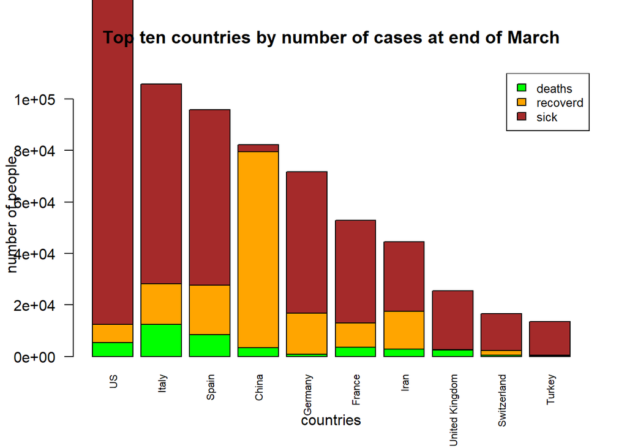

```r
# change the data frame to matrix for building the bar plot
matrix_value <- data.matrix(march_top_10, rownames.force = NA) # replace table to matrix
matrix_value <- t(matrix_value)
matrix_value <- matrix_value[-1,]

#build the bar plot which shows in total that cases= sick+ recovored + death
colors = c("green","orange","brown")
countries <- c('US', 'Italy', 'Spain', 'China', 'Germany','France','Iran', 'United Kingdom', 'Switzerland', 'Turkey')
regions <- c("deaths", "recoverd","sick")
barplot(matrix_value, main = "Top ten countries by number of cases at end of March", names.arg = countries, xlab = "countries", ylab = "number of people", col = colors, ylim = c(0,110000),las = 2,cex.names = 0.7)
legend("topright", regions, cex = 0.8, fill = colors)
```

the issue with the bar plot is that there is a data that we can not see because of the big diffrencces between countries or diffrencces between sick, recovered and deaths. for example, in Turkey its almost impossible to see the deaths ane recovered.

### Q2

### Analysis of Daily New Corona Cases and Deaths

20 points

**Solution:** A:

```r
#create new column that show how many new cases/deaths each country incurs each day
deaths.agg.new <- deaths.agg %>% group_by(Country.Region) %>% mutate(diff = Value - lag(Value, default = Value[1]))
cases.agg.new <- cases.agg %>% group_by(Country.Region) %>% mutate(diff = Value - lag(Value, default = Value[1]))
```

B:

```r
#print in descriptive format the top 10 deaths and cases
top_deaths <- head(arrange(deaths.agg.new, desc(diff)),10)
print(top_deaths)
```

```
## # A tibble: 10 x 4
## # Groups:   Country.Region [1]
##    Country.Region Date       Value  diff
##    <chr>          <date>     <int> <int>
##  1 US             2020-04-29 60967  2612
##  2 US             2020-04-17 37411  2584
##  3 US             2020-04-15 32734  2472
##  4 US             2020-04-21 45086  2427
##  5 US             2020-04-14 30262  2392
##  6 US             2020-04-18 39753  2342
##  7 US             2020-04-22 47412  2326
##  8 US             2020-04-23 49724  2312
##  9 US             2020-04-07 16191  2297
## 10 US             2020-04-25 53755  2262
```

```r
top_cases <- head(arrange(cases.agg.new, desc(diff)),10)
print(top_cases)
```

```
## # A tibble: 10 x 4
## # Groups:   Country.Region [1]
##    Country.Region Date        Value  diff
##    <chr>          <date>      <int> <int>
##  1 US             2020-04-24 905358 36188
##  2 US             2020-04-09 462780 34126
##  3 US             2020-04-10 496535 33755
##  4 US             2020-04-04 308650 33283
##  5 US             2020-04-25 938154 32796
##  6 US             2020-04-18 732197 32491
##  7 US             2020-04-17 699706 32114
##  8 US             2020-04-03 275367 31745
##  9 US             2020-04-08 428654 31533
## 10 US             2020-04-16 667592 31242
```

c:

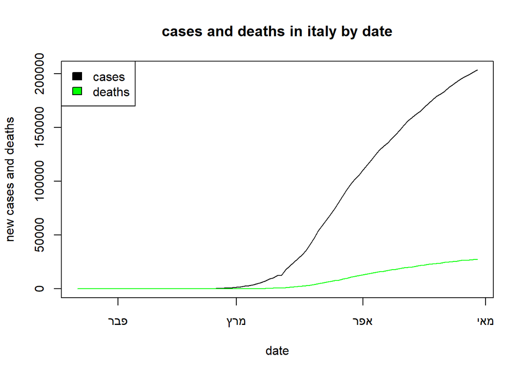

```r
#create new data frame od Italy deaths and cases
deaths_italy <- filter(deaths.agg,Country.Region == "Italy")
cases_italy <- filter(cases.agg,Country.Region == "Italy")
italy <- full_join(deaths_italy,cases_italy,"Date")
italy <- slice(italy) %>% select( Date, Value.x, Value.y)
names(italy)[2] <- "deaths"
names(italy)[3] <- "cases"

plot(x= italy$Date, y= italy$cases,type='l', col = "black", xlab= "date", ylab= "new cases and deaths", main= "cases and deaths in italy by date")
lines(x= italy$Date , y= italy$deaths, col= "green")
legend("topleft", legend = c("cases","deaths"), fill = c("black", "green"))
```

```r
# create a plot that shows cases and deaths in italy by date
```

D:

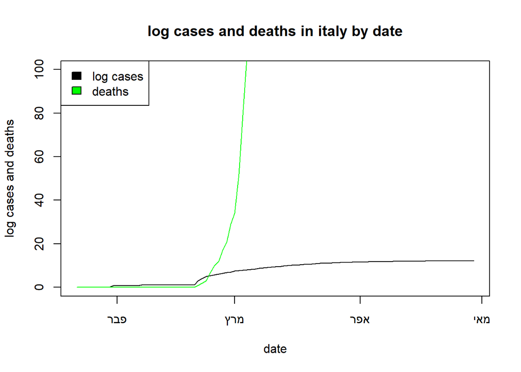

```r
italy$cases <-log(italy$cases)
italy <- italy %>% mutate_if(is.numeric, function(x) ifelse(is.infinite(x), 0, x))
# create a plot that shows  log cases and deaths in italy by date
plot(x= italy$Date, y= italy$cases ,type='l', col = "black", xlab= "date", ylab= "log cases and deaths",main= "log cases and deaths in italy by date",  ylim = c(0,100))
lines(x= italy$Date , y= italy$deaths, col= "green")
legend("topleft", legend = c("log cases","deaths"), fill = c("black", "green"))
```

in this graph we show the same grafh as in 2c but we did log only for the cases value. now we can see that the scale is out of proportion and we cant figure a good data from this graph.

### Q3

### Preparing and Analyzing the World Bank Data

25 points

**Solution:**

```r
eco_data <- read.csv(url("https://raw.githubusercontent.com/DataScienceHU/DataAnalysisR_2020/master/data/economic_data.csv"), stringsAsFactors = FALSE)
# rename columns as required
names(eco_data)[1] <- "country"
names(eco_data)[2] <- "S_country"
names(eco_data)[3] <- "feature"
names(eco_data)[4] <- "feature_code"
names(eco_data)[5] <- "Y2018V"
names(eco_data)[6] <- "Y2019V"
```

B, c:

```r
# new data frame that shows countries and the features with their respective values in eco-data
eco <- eco_data %>% select(country,feature,Y2018V)
eco <- eco[-c(2641,2642,2643),]

eco <- spread(eco, feature, Y2018V, fill = NA, convert = FALSE, drop = TRUE,
  sep = NULL )
eco <- slice(eco) %>% select(1,3,4,5,6,7,8,9,10,11,12)
head_eco<- head(eco)
print(head_eco)
```

```
##          country GDP (constant LCU) GDP (current US$)
## 1    Afghanistan   511432475534.156  19362969582.3643
## 2        Albania      1513259270000   15102500898.238
## 3        Algeria   6123376375970.86   173757952824.25
## 4 American Samoa          608000000         636000000
## 5        Andorra         2002840000  3236543909.34844
## 6         Angola      1552771000000   105750987618.63
##   GDP, PPP (current international $)
## 1                   72672245387.0863
## 2                   38306694289.2319
## 3                   653771569286.319
## 4                                 ..
## 5                                 ..
## 6                   198795526982.065
##   Government expenditure on education, total (% of GDP)
```

[output cut: 41 more lines]

```r
# rename columns as required
names(eco)[1] <- "country"
names(eco)[3] <- "GDP"
names(eco)[6] <- "pop65"
names(eco)[7] <- "pop_city_ratio"
names(eco)[8] <- "pop_total"
```

D:

```r
eco$GDP <- as.numeric(as.character(eco$GDP))
eco$pop_total <- as.numeric(as.character(eco$pop_total))
# create new column - GDP per capita named GDP_POP
eco <- eco %>% mutate(GDP_POP = GDP / pop_total)
eco[is.na(eco)] <- 0
# 5 COUNTRIES WITH THE HIGHEST GDP PER CAPITA IN 2018
top_GDP <- head(arrange(eco, desc(GDP_POP)),5)
print(top_GDP)
```

```
##            country GDP (constant LCU)          GDP
## 1           Monaco   5720647180.37038   7184844193
## 2       Luxembourg        57152595000  70885325883
## 3 Macao SAR, China       429497000000  55084050790
## 4      Switzerland       696139480200 705140354166
## 5           Norway      3259053000000 434166615432
##   GDP, PPP (current international $)
## 1                                 ..
## 2                   68878323882.4048
## 3                   78254752438.0468
## 4                   579643931032.338
## 5                   348145261704.001
##   Government expenditure on education, total (% of GDP)            pop65
## 1                                                    ..               ..
## 2                                                    .. 14.1831541841472
```

[output cut: 27 more lines]

```r
# slice the 10% countries with the lowest GDP per capita
top90_GDP <- eco %>% filter(GDP_POP > quantile(eco$GDP_POP, 0.10))
top90_GDP$pop65 <- as.numeric(as.character(top90_GDP$pop65))
```

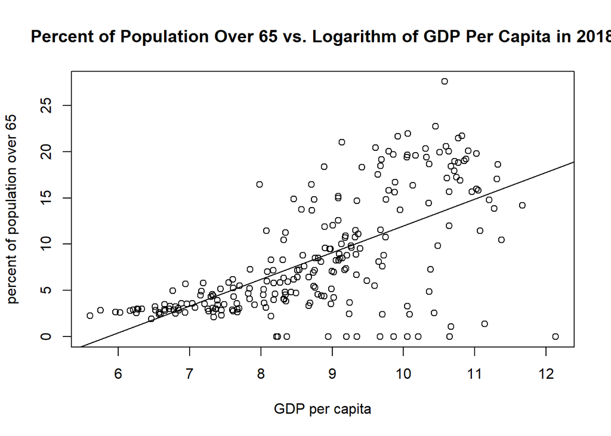

```r
top90_GDP$GDP_POP <- as.numeric(as.character(top90_GDP$GDP_POP))
top90_GDP[is.na(top90_GDP)] <- 0

#plot the % of population over 65 vs. log of GDP per capita in 2018
plot(x = log(top90_GDP$GDP_POP), y= top90_GDP$pop65, xlab = "GDP per capita", ylab = "percent of population over 65", main= "Percent of Population Over 65 vs. Logarithm of GDP Per Capita in 2018")
abline(lm(top90_GDP$pop65~log(top90_GDP$GDP_POP),top90_GDP))
```

we can learn from the plot and the regression line in it that there is a positive correlation between the % of population over 65 vs. log of GDP per capita in 2018, which means that the older the population the GDP per capita is higher

### Q4

### Joining the Datasets

20 points

A: **Solution:**

```r
#join the data frames
corona <- full_join(full_join(recovered.agg,deaths.agg,by =c("Date","Country.Region"), copy = FALSE),cases.agg, by =c("Date","Country.Region"), copy = FALSE)
names(corona)[3] <- "recovered1"
names(corona)[4] <- "deaths1"
names(corona)[5] <- "cases1"
```

B:

```r
names(corona)[1] <- "country"
# matching names of countries in the 2 data frames
eco$country[eco$country == "Myanmar"] <- "Burma"
eco$country[eco$country == "Gambia, The"] <- "Gambia"
eco$country[eco$country == "Syrian Arab Republic"] <- "Syria"
eco$country[eco$country == "Congo, Dem. Rep."] <- "Congo (Kinshasa)"
eco$country[eco$country == "St. Kitts and Nevis"] <- "Saint Kitts and Nevis"
eco$country[eco$country == "Iran, Islamic Rep. "] <- "Iran"
eco$country[eco$country == "Brunei Darussalam"] <- "Brunei"
eco$country[eco$country == "Sub-Saharan Africa"] <- "Western Sahara"
eco$country[eco$country == "St. Vincent and the Grenadines"] <- "Saint Vincent and the Grenadines "
eco$country[eco$country == "Kyrgyz Republic"] <- "Kyrgyzstan"
eco$country[eco$country == "Bahamas, The"] <- "Bahamas"
eco$country[eco$country=="Congo, Rep."]<-"Congo (Brazzaville)"
eco$country[eco$country=="Czech Republic"]<-"Czechia"
eco$country[eco$country=="Egypt, Arab Rep."]<-"Egypt"
eco$country[eco$country=="Korea, Rep."]<-"Korea, South"
eco$country[eco$country=="Lao PDR"]<-"Laos"
eco$country[eco$country=="Russian Federation"]<-"Russia"
eco$country[eco$country=="St. Lucia"]<-"Saint Lucia"
eco$country[eco$country=="Slovak Republic"]<-"Slovakia"
eco$country[eco$country=="Venezuela, RB"]<-"Venezuela"
eco$country[eco$country=="Yemen, Rep."]<-"Yemen"
eco$country[eco$country == "United States"] <- "US"
# merge the eco and corona data frames
corona_eco <-merge(eco,corona)
corona_eco[is.na(corona_eco)] <- 0
```

c:

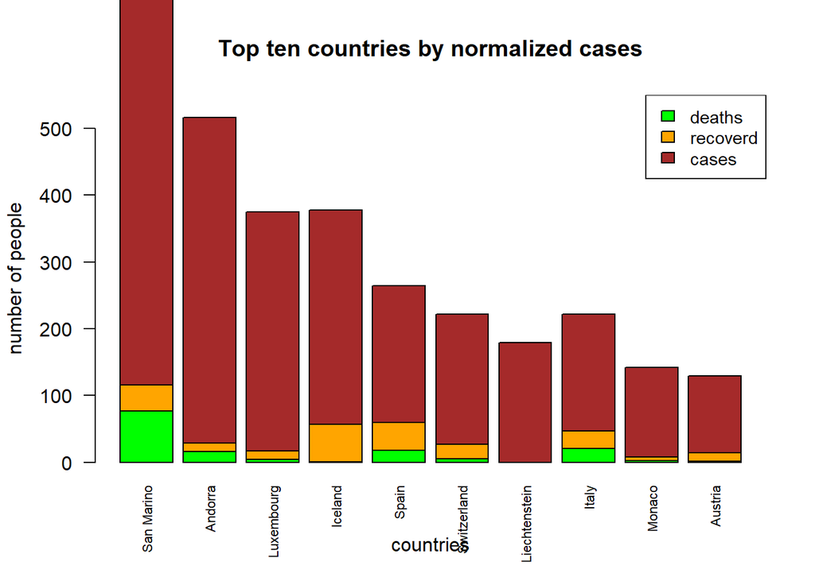

```r
corona_eco$pop_total <- as.numeric(as.character(corona_eco$pop_total))
corona_eco$cases1 <- as.numeric(as.character(corona_eco$cases1))
corona_eco$deaths1 <- as.numeric(as.character(corona_eco$deaths1))
corona_eco$recovered1 <- as.numeric(as.character(corona_eco$recovered1))

#Creating new columns of cases,deaths, and recovered per 100,000 people for each country.
corona_eco <- corona_eco %>% mutate(cases = 100000 * cases1 / pop_total )
corona_eco <- corona_eco %>% mutate(deaths = 100000 * deaths1 / pop_total )
corona_eco <- corona_eco %>% mutate(recovered = 100000 * recovered1 / pop_total )
corona_eco <- corona_eco %>% mutate_if(is.numeric, function(x) ifelse(is.infinite(x), 0, x))

#Using the last day of March as a reference

corona_eco <- corona_eco[which(corona_eco$Date == "2020-03-31"), ]
corona_eco <- filter(corona_eco,country == country )

#slicing to show only normalized data
corona_eco_plot <- slice(corona_eco) %>% select(country, cases, deaths, recovered)

#showing the top 10 countries
corona_eco_plot <- corona_eco_plot[order(corona_eco_plot$cases, decreasing = TRUE), ]
corona_eco_top_10 <- head(corona_eco_plot[, !names(corona_eco_plot) == "Cases"], 10)

corona_eco_top_10 <- slice(corona_eco_top_10) %>% select(deaths, recovered, cases)
value_matrix <- data.matrix(corona_eco_top_10, rownames.force = NA)
value_matrix <- t(corona_eco_top_10)

#barplot for the top 10 countries
colors = c("green","orange","brown")
country <- c('San Marino','Andorra','Luxembourg','Iceland', 'Spain', 'Switzerland', 'Liechtenstein', 'Italy', 'Monaco', 'Austria')
regions <- c("deaths", "recoverd","cases")
barplot(value_matrix, main = "Top ten countries by normalized cases", names.arg = country, xlab = "countries", ylab = "number of people", col = colors, ylim = c(0,550),las = 2,cex.names = 0.7)
legend("topright", regions, cex = 0.9, fill = colors)
```

as we can see the top 10 countries are different between the 2 plots. it may be more meaningful to look at this plot since it reflects the spredness of the virus in each country regardless of the size of the population.

D:

```r
corona_eco$pop65 <- as.numeric(as.character(corona_eco$pop65))
```

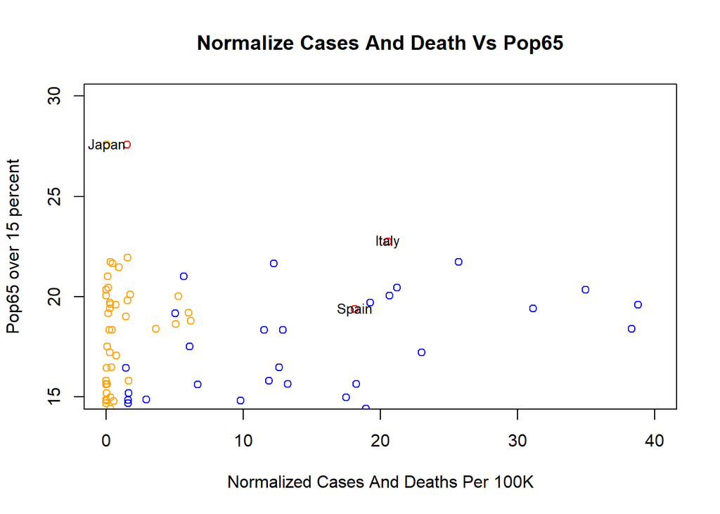

```r
rownames(corona_eco)<- corona_eco$country

plot_normal_VS_pop65 <- plot(x = corona_eco$deaths,y= corona_eco$pop65 ,xlab= "Normalized Cases And Deaths Per 100K",ylab = "Pop65 over 15 percent",col = (ifelse(corona_eco$deaths > 15 ,"red","orange")) ,xlim=c(0,40),ylim = c(15,30),main = "Normalize Cases And Death Vs Pop65") #build the plot
points(corona_eco$cases,corona_eco$pop65,col=ifelse(corona_eco$pop65 > 24 ,"red","blue"))
text(pop65~ deaths,labels = ifelse(corona_eco$deaths > 15 | corona_eco$pop65>24,rownames(corona_eco),NA),data=corona_eco, cex=0.8, font=0.6) #adding labels
```

### Q5

### Open Question

10 points

Write an interesting research question regarding the Corona outbreak and then follow the steps to answer it using tables and plots. You can use the loaded datasets or any other dataset you find as long as you add the data file to your `lab1` repository so it can be loaded directly from a `url` (e.g. the World Bank). This question will be graded based on creativity, originality, and the novelty of the analysis.

**Solution:**

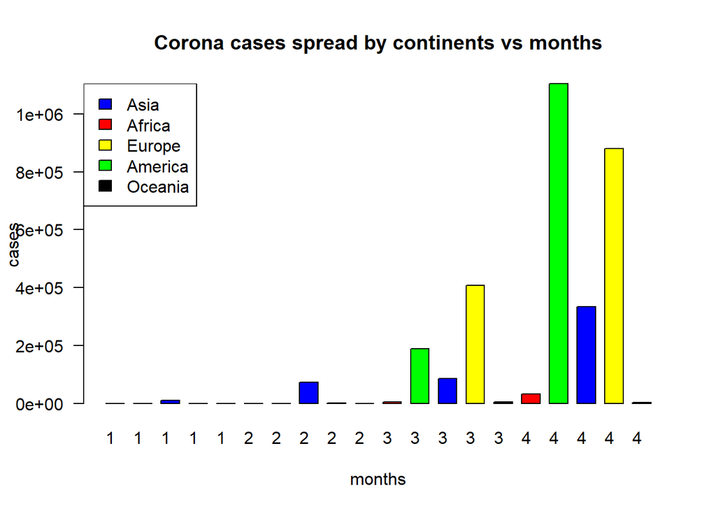

```r
mainland_data <- read.csv(url("https://data.humdata.org/hxlproxy/api/data-preview.csv?url=https%3A%2F%2Fopendata.ecdc.europa.eu%2Fcovid19%2Fcasedistribution%2Fcsv&filename=ecdc_covid19_cases.csv"))

cases.conti <- mainland_data %>% group_by(continentExp, month) %>%
    summarise(cases = sum(cases)) %>% arrange(month)
cases.conti  <-cases.conti[-c(which(cases.conti$continentExp == "Other")), ]
cases.conti <- cases.conti[-c(which(cases.conti$month == "12")), ]

case_matrix<- cbind(cases.conti$continentExp, cases.conti$cases)
rownames(case_matrix) <- cases.conti$month

bp <-barplot(t(case_matrix),beside = TRUE, c(0,2000),las = 2,cex.names = 1,las = 1, col=c("blue","red", "yellow", "green", "black"),xlab = "months",ylab = "cases", main = "Corona cases spread by continents vs months")
legend("topleft", legend = c("Asia","Africa","Europe","America","Oceania"), fill = c("blue","red", "yellow", "green", "black"))
```

We would like to see if there is a significant difference in the outbreak of the Corona epidemic between the different continents.

It can be seen that according to the graph we have created showing the number of cases on each continent every month that although the epidemic started in Asia, the increase in the number of cases there is quite moderate. in particular,the increase in continents which most of there countries are first world countries is greatest (America,Europe). we also can see that the Corona epidemic is not spreaded at Oceania and Africa as much as in the other continents, but in Africa we can see that there is a growing trend in the number of cases mostly in this month (April) and we can assumme by this graph that the number will increase much more in the future (based on spread in other continents).

According to this graph, it is not possible to understand why the change in spread exists. there is factors like Asia past experience in dealing with epidemics, number of tests, weather conditions, average age on each continent or transparency towards the public. we believe, an answer that accurately describes the difference may be obtained after the epidemic is over and it should be explored by all different factors, but in the meantime we learn that there is a significant difference between continents in both the number of cases and the growth rate.